# Impact of Review Scores on Physical Game Sales

This is data gathered from vgchartz, metacritic, and igdb scraped using python using a scrapper that can be found here  
Thankfully there are around 4,190 games that have review scores on metacritic, and sales data available vgchartz, unfortunately the data is measured in incriments of 10,000 sales so it is not as accurate as I would like. Digital sales are not included either so this analysis is strictly on physical sales.

# Distribution of Data

Taking a look at the distribution of data its clear that it is highly skewed.

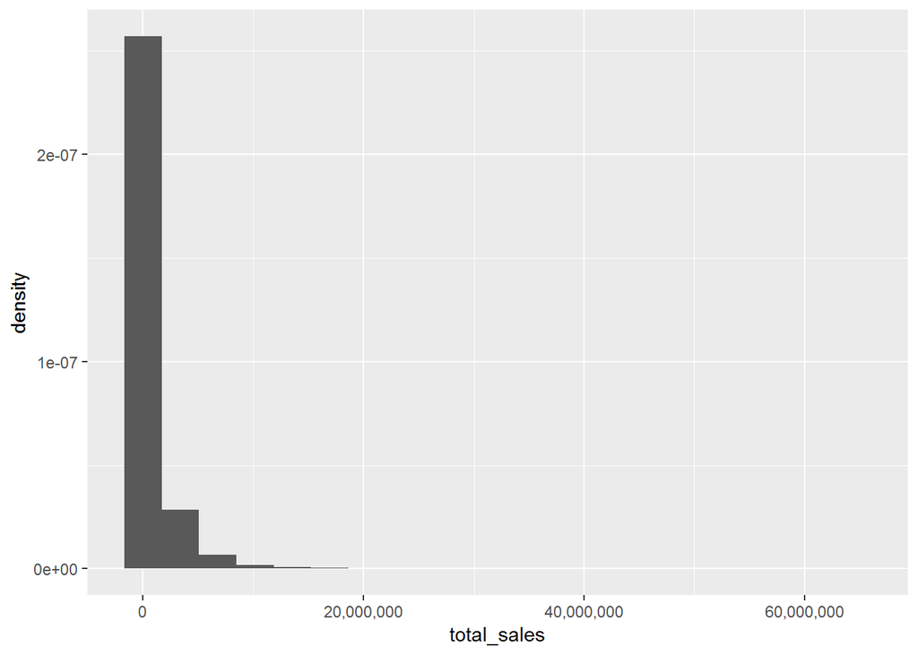

In order to analyze the data further I will take the log of total sales in order to normalize the distribution.

```r
#Taking log of sales
full_data_merged_plats$log_total_sales<-log(full_data_merged_plats$total_sales)
```

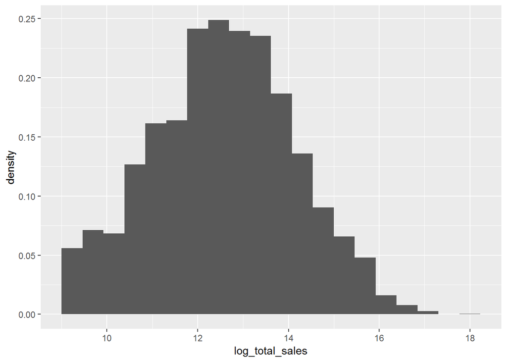

### Review Scores

As an avid gamer I have first hand knowledge of some of the factors which impact video game sale. Critic and user scores are something that every gamer I know looks at before buying a game (and especially people buying games as a gift). This is univariate regression for both critic & user scores.

It does seem like aggragate critic review scores have an impact on game sales, albeit a small one

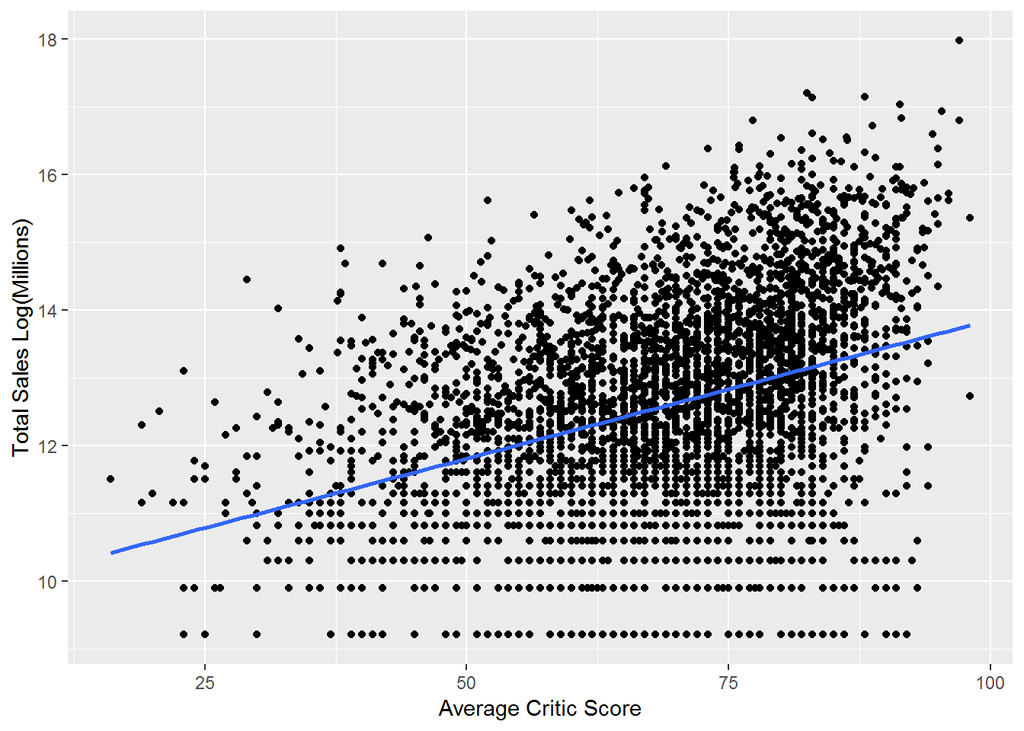

```r
summary(avg_critic_scores_lm)
```

```
##
## Call:
## lm(formula = log_total_sales ~ avg_critic_score, data = full_data_merged_plats)
##
## Residuals:
##     Min      1Q  Median      3Q     Max
## -4.3216 -0.9485  0.0574  1.0055  4.2423
##
## Coefficients:
##                  Estimate Std. Error t value Pr(>|t|)
## (Intercept)      9.765463   0.116058   84.14   <2e-16 ***
## avg_critic_score 0.040940   0.001654   24.75   <2e-16 ***
## ---
## Signif. codes:  0 '***' 0.001 '**' 0.01 '*' 0.05 '.' 0.1 ' ' 1
##
## Residual standard error: 1.444 on 4187 degrees of freedom
## Multiple R-squared:  0.1276, Adjusted R-squared:  0.1274
## F-statistic: 612.4 on 1 and 4187 DF,  p-value: < 2.2e-16
```

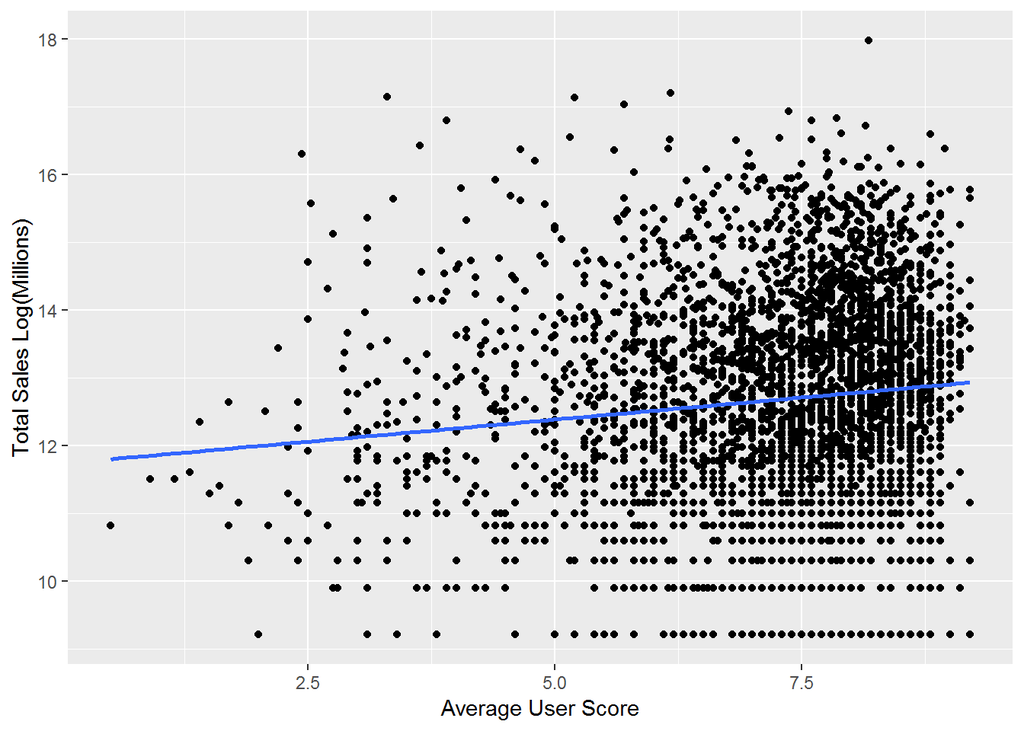

```r
summary(avg_user_scores_lm)
```

```
##
## Call:
## lm(formula = log_total_sales ~ avg_user_score, data = full_data_merged_plats)
##
## Residuals:
##     Min      1Q  Median      3Q     Max
## -3.7240 -1.0439 -0.0044  1.0070  5.1779
##
## Coefficients:
##                Estimate Std. Error t value Pr(>|t|)
## (Intercept)     11.7373     0.1397  84.020  < 2e-16 ***
## avg_user_score   0.1301     0.0190   6.849 8.71e-12 ***
## ---
## Signif. codes:  0 '***' 0.001 '**' 0.01 '*' 0.05 '.' 0.1 ' ' 1
##
## Residual standard error: 1.531 on 3606 degrees of freedom
##   (581 observations deleted due to missingness)
## Multiple R-squared:  0.01284,    Adjusted R-squared:  0.01257
## F-statistic: 46.91 on 1 and 3606 DF,  p-value: 8.712e-12
```

Number of platforms that a game is available on also have a big impact, since the majority of people only have one or two consoles.

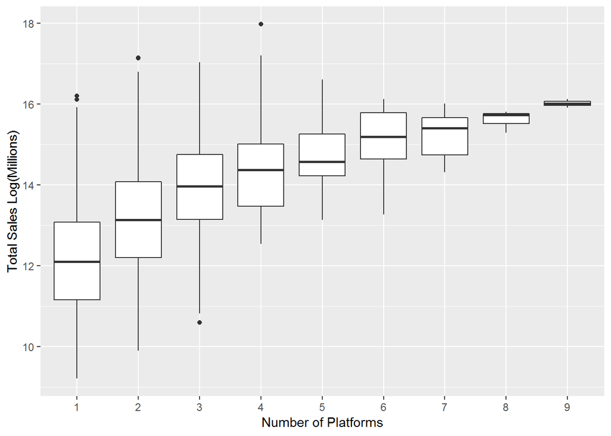

```r
summary(num_plats_lm)
```

```
##
## Call:
## lm(formula = log_total_sales ~ number_platforms, data = full_data_merged_plats)
##
## Residuals:
##     Min      1Q  Median      3Q     Max
## -3.0884 -0.9433  0.0218  0.9570  4.2276
##
## Coefficients:
##                  Estimate Std. Error t value Pr(>|t|)
## (Intercept)      11.40844    0.03936   289.9   <2e-16 ***
## number_platforms  0.75888    0.02150    35.3   <2e-16 ***
## ---
## Signif. codes:  0 '***' 0.001 '**' 0.01 '*' 0.05 '.' 0.1 ' ' 1
##
## Residual standard error: 1.357 on 4187 degrees of freedom
## Multiple R-squared:  0.2293, Adjusted R-squared:  0.2291
## F-statistic:  1246 on 1 and 4187 DF,  p-value: < 2.2e-16
```

# Multiple linear regression

Combining the variables above along with genre, esrb rating, multiplayer, wether the game is a part of a series, developer and budget I will now try to build a model to predict a game’s sales. Since I cannot find a reliable source of game budget data I will use publishers since they are deeply involved with the funding.

```r
summary(sales_model)
```

```
##
## Call:
## lm(formula = log_total_sales ~ avg_critic_score + release_date +
##     number_platforms + release_date + developer + esrb_rating +
##     publisher + multiplayer + genre + series, data = full_data_merged_plats)
##
## Residuals:
##     Min      1Q  Median      3Q     Max
## -4.9089 -0.3511  0.0000  0.3959  3.0997
##
## Coefficients: (70 not defined because of singularities)
##                                                                          Estimate
## (Intercept)                                                             9.382e+00
## avg_critic_score                                                        3.102e-02
## release_date                                                            5.535e-05
## number_platforms                                                        5.351e-01
## developer1C Maddox Games                                               -5.081e+00
## developer1C: Maddox Games                                              -3.536e+00
## developer1st Playable Productions                                      -1.734e+00
## developer2015, Inc.                                                    -1.029e+00
## developer2D Boy                                                        -3.869e+00
## developer2K Australia / 2K Boston                                      -2.436e-01
## developer2K Games                                                       5.785e-01
## developer2K Marin                                                      -1.791e+00
## developer2K Shanghai                                                   -6.208e-01
## developer2K Sports                                                     -2.166e+00
## developer2XL Games                                                     -1.444e+00
## developer343 Industries                                                 4.167e-01
## developer369 Interactive                                               -1.393e+00
## developer38 Studios                                                    -7.893e-01
## developer3D Realms                                                     -2.607e+00
## developer3d6 Games                                                     -1.706e+00
## developer3DClouds.it                                                   -1.893e+00
## developer3DO                                                           -5.124e-01
## developer3G Studios                                                    -2.023e+00
## developer49Games                                                       -8.634e-01
## developer4a-games                                                      -5.540e-01
## developer4J Studios                                                    -1.179e+00
## developer4mm Games / Terminal Reality                                  -7.521e-01
## developer5000ft                                                        -2.973e+00
```

[output cut: 8163 more lines]

```
## genreRacing
## genreRole-Playing
## genreShooter
## genreSimulation
## genreSports
## genreStrategy                                                          ***
## genreVisual+Novel
## seriesyes                                                              ***
## ---
## Signif. codes:  0 '***' 0.001 '**' 0.01 '*' 0.05 '.' 0.1 ' ' 1
##
## Residual standard error: 0.9773 on 2619 degrees of freedom
##   (1 observation deleted due to missingness)
## Multiple R-squared:  0.7499, Adjusted R-squared:  0.6002
## F-statistic: 5.009 on 1568 and 2619 DF,  p-value: < 2.2e-16
```